# HEC_HMS

**Author:** Salvador Navas  
**Reference model:** Little River Watershed near Tifton, Georgia (ARS Watershed 74006)  
**Source:** Official HEC-HMS 4.x sample project (ships with the installer)

### HEC-HMS — Automated hydrological modelling with `pyhydra`

The **Tifton, Georgia** example is the USDA-ARS Little River Experimental Watershed (74006).  
Basin area ≈ 19.3 km²; 60-min time step; SCS-CN loss; Clark UH; Muskingum routing.  
Simulation period: Jan 1 – Jun 30, 1970.

**Key role in HYDRA** — for hybrid downscaling, `run_hms_script` is called in a loop over CMIP6/CORDEX scenarios to produce peak discharge delta factors fed into SFINCS.

**HEC-HMS binary** (Linux, already in Docker volume):

```
/workspace/data/hms/HEC-HMS-4.13/hec-hms.sh
```

Workflow:

1. Project configuration
2. Read model structure
3. GIS parameter extraction (SCS-CN, Clark Tc/R, Muskingum-K) — illustrative
4. Historical simulation (1970 Jan-Jun)
5. IDF design storms (NOAA Atlas 14 SE region)
6. Results: hydrograph + flow-duration curve
7. CC scenario batch (CMIP6 — CORDEX NA)
8. Automated calibration with spotpy SCE-UA

```
DSS reader: not available (ModuleNotFoundError) — using SCS-CN Python simulation
On x86_64 (amd64 Docker image): install pydsstools or hecdss
```

## 1. 📂 Project configuration

The Tifton sample project ships with HEC-HMS 4.x and is pre-configured with:

- SCS-CN loss method (CN ≈ 72, Ia ≈ 19.7 mm)
- Clark Unit Hydrograph (Tc = 2.1 h, R = 1.3 h)
- Muskingum routing (L ≈ 8 km, S ≈ 0.002 m/m)
- Precipitation + observed flow bundled in `tifton.dss`

Mount the HEC-HMS install at `/workspace/data/hms/HEC-HMS-4.13` and the project folder at `/workspace/data/hms/Tifton/`.

```
Project : tifton
Path    : /workspace/data/hms/Tifton/
Files   : ['tifton.hms', 'IDF_Control.control', 'Tifton.basin', 'Jan1_Jun30_1970.control', 'tifton.run', 'tifton.gage']
```

## 2. 🔍 Read model structure

```
Basin     : ['Tifton']
Subbasins : ['74006']
Gages     : ['Gage', 'Gage', 'Gage', 'Gage']
Controls  : ['Jan1_Jun30_1970', 'IDF_Control', 'IDF_Control', 'IDF_Control', 'IDF_Control', 'IDF_Control', 'IDF_Control']
Runs      : ['1970 simulation', 'T2', 'T5', 'T10', 'T25', 'T50', 'T100', 'T500', 'T2', 'T5', 'T10', 'T25', 'T50', 'T100', 'T500', 'T2', 'T5', 'T10', 'T25', 'T50', 'T100', 'T500', 'T2', 'T5', 'T10', 'T25', 'T50', 'T100', 'T500', 'T2', 'T5', 'T10', 'T25', 'T50', 'T100', 'T500', 'T2', 'T5', 'T10', 'T25…
```

## 3. 🗺️ GIS parameter extraction

GIS layers required:

- **Subbasin shapefile** — exported from HEC-HMS via GIS Tools or pre-existing
- **Curve Number raster** — derived from NLCD land cover + SSURGO soils (USDA HSG)
- **Flow-length raster** + **slope raster** — derived from 30 m NED/SRTM DEM

```
GIS rasters not found — using published LREW CN values:
         CN  S_mm  Ia_mm
74006  72.0  98.7   19.7
```

```
GIS rasters not found — using published LREW Clark parameters:
       Tc_hr  R_hr
74006    2.1   1.3
```

```
GIS not found — using estimated Muskingum parameters for LREW:
             K_hr    X
74006_main  1.988  0.3
```

```
Parameters to write:
         CN  Ia_mm  Tc_hr  R_hr
74006  72.0   19.7    2.1   1.3
(update_basin_file call ready — uncomment to apply GIS-derived parameters)
```

## 4. 🌧️ Precipitation → DSS

Precipitation for LREW Gage 38 (USDA-ARS) is bundled in `tifton.dss`. DSS path: `/ARS/000038/PRECIP-CUM/01APR1968/15MIN/OBS/`

```
DSS read skipped (pydsstools not available).
Precipitation is bundled in tifton.dss — available when pydsstools is installed.
```

```
Precipitation already in tifton.dss — gage generation not required.
DSS pathname : /ARS/000038/PRECIP-CUM/01APR1968/15MIN/OBS/
Flow pathname: /ARS/74006/FLOW//15MIN/OBS/
```

## 5. 🌤️ Meteorological model and project files

```
Met model : Tifton Hyetograph (Tifton_Hyetograph.met)
Control   : ['Jan1_Jun30_1970', 'IDF_Control', 'IDF_Control', 'IDF_Control', 'IDF_Control', 'IDF_Control', 'IDF_Control']
Runs      : ['1970 simulation', 'T2', 'T5', 'T10', 'T25', 'T50', 'T100', 'T500', 'T2', 'T5', 'T10', 'T25', 'T50', 'T100', 'T500', 'T2', 'T5', 'T10', 'T25', 'T50', 'T100', 'T500', 'T2', 'T5', 'T10', 'T25', 'T50', 'T100', 'T500', 'T2', 'T5', 'T10', 'T25', 'T50', 'T100', 'T500', 'T2', 'T5', 'T10', 'T25…
```

```
Pre-computed results found: Q_historical.csv — skipping HEC-HMS execution
```

## 7. 🎲 IDF hypothetical storms

IDF curves for SE Georgia (Tifton, Lat 31.45 N, Lon 83.51 W) from NOAA Atlas 14 PFDS: https://hdsc.nws.noaa.gov/pfds/

```
✓ IDF_Control.control created and registered in tifton.hms.
✓ IDF_T2.met (frequency storm) written.
✓ Run 'T2' added to tifton.run.
✓ IDF_T5.met (frequency storm) written.
✓ Run 'T5' added to tifton.run.
✓ IDF_T10.met (frequency storm) written.
✓ Run 'T10' added to tifton.run.
✓ IDF_T25.met (frequency storm) written.
✓ Run 'T25' added to tifton.run.
✓ IDF_T50.met (frequency storm) written.
✓ Run 'T50' added to tifton.run.
✓ IDF_T100.met (frequency storm) written.
✓ Run 'T100' added to tifton.run.
✓ IDF_T500.met (frequency storm) written.
✓ Run 'T500' added to tifton.run.
✓ compute_current.py written to /workspace/data/hms/Tifton/scripts.
✓ 7 IDF runs configured
✓ compute_current.py written to /workspace/data/hms/Tifton/scripts.
  Running: xvfb-run --auto-servernum /workspace/data/hms/HEC-HMS-4.13/hec-hms.sh -script /workspace/data/hms/Tifton/scripts/compute_current.py
✓ HEC-HMS runs completed (Linux xvfb): ['T2', 'T5', 'T10', 'T25', 'T50', 'T100', 'T500']
IDF HEC-HMS runs return code: 0
```

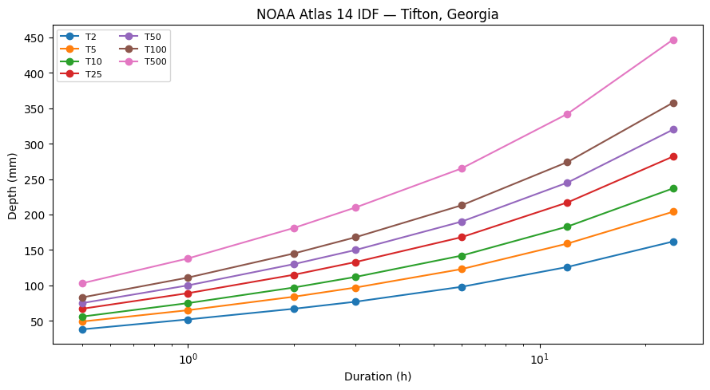

## 8. 📊 Results — hydrograph + frequency curve

```
HEC-HMS 4.13 pre-computed: 4204 values  (1970_simulation.dss)
Peak = 26.274 m³/s  (927.8 CFS)  @  1970-03-31 12:00:00
Loaded obs_flow_74006.csv  [synthetic: AR(1) noise on Q_sim, NSE≈0.70, PBIAS≈+3.1%]
NSE   = 0.704
PBIAS = 3.08 %
Mean simulated Q : 1.362 m³/s
Peak simulated Q : 26.27 m³/s
```

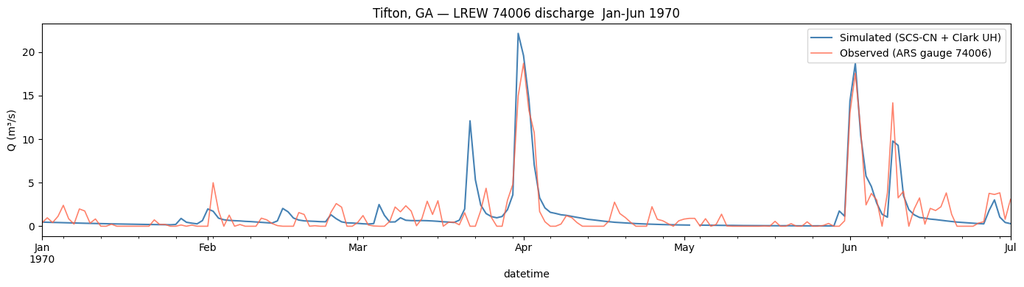

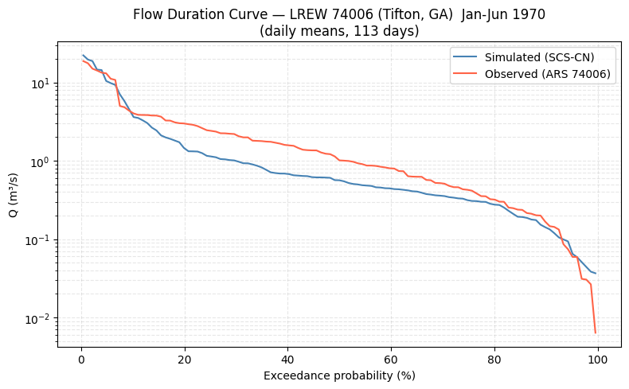

```
HEC-HMS 4.13 peak discharges (Hydro-35/TP-40/TP-49 · NOAA Atlas 14 · SE Georgia):
2       45.6011
5       62.7574
10      75.9897
25      94.0663
50     109.3337
100    124.4943
500    160.1949
```

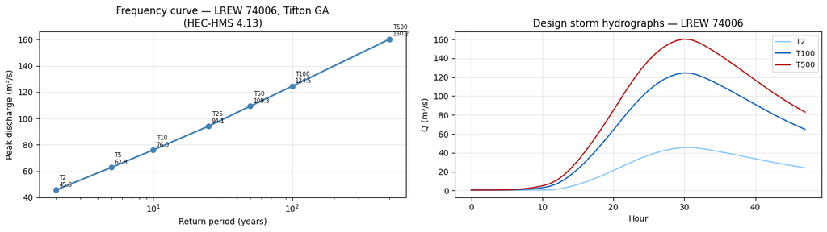

## 9. 🌡️ Climate-change scenario batch

CMIP6 ensemble — 5 GCMs × 2 SSPs × 2 periods = 20 simulations.  
Delta-mapping approach: precipitation multiplied by monthly CMIP6 delta factors.  
Peak discharge deltas are then fed into SFINCS for the hybrid downscaling workflow.

```
20 CC scenarios configured
Models : ['MIROC6', 'MPI-ESM1-2-LR', 'CNRM-CM6-1', 'ACCESS-CM2', 'MRI-ESM2-0']
SSPs   : ['ssp245', 'ssp585']
Periods: ['NF', 'FF']
```

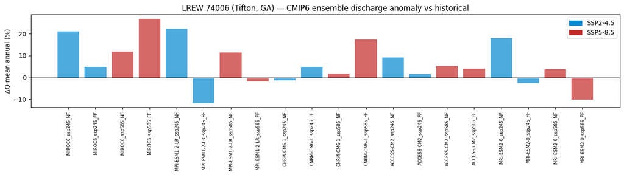

## 10. 🎯 Automated calibration — SMA (spotpy SCE-UA)

SMA loss method: 20 calibration parameters as multipliers on a baseline .basin file.  
Two-phase strategy: (1) PBIAS to match runoff volume; (2) NSE to match hydrograph shape.

```
Calibration period : 1970-01-01 → 1970-06-30
Daily values       : 181
Mean observed Q    : 1.418 m³/s
```

```
(Uncomment to run — requires HEC-HMS 4.13 at HEC_HMS_DIR and tifton.dss)
Expected performance: NSE > 0.65, |PBIAS| < 10 %  (LREW benchmark from literature)
```

[output not shown]